# Shiny Paper on Mobile Phones with JO

MT, JO

2017-05-06

runtime: shiny (add above)

# Abstract

Here I try to document what we did with JO[^1] for **NECTAR2017** in presentation “An exploration of Digital traces of urban flows: cell phone data census of mobility”.

# Presentation

### Intro

lots of interest in OD matrices (in fact we are funded for that)

but data often are either:

- too rarely sampled (e.g., surveys, census)
- imprecise - phone call records, too sparse events
- precise but computationally intensive
- precise but unavailable

so can one use cell phone data to get a valid, large-scale assessment?

- yes (Calabrese et al, 2015)

### Cell phone based location estimation methods

Network based: e.g. Cell-Id positioning (easier to implement for us) or triangulation (computationally intensive) Handset based location services: e.g. GPS (people opt out for privacy, heavy battery usage) Hybrid: e.g. network- assisted A-GPS (precise but same problems as with GPS) Wi-Fi based (need access to routers) (Steenbruggen et al., 2013; Calabrese et al., 2015)

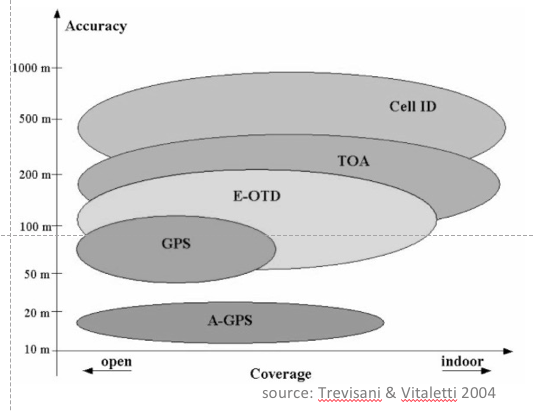

Trevisani & Vitaletti 2004

### So what do we do?

we compare 2 datasets: **census data** (PLACE) with **cell phone data** (MIND) to assess convergent validity

#### PLACE database (Statistics Sweden SCB)

Anonymised longitudinal registers all individuals 16 years of age and older that were registered in Sweden as of December 31 for each year, here we use employed individuals only in November)

Data: education, income, demography, employment  
Location: geography on workplaces and housing (coordinates at 100m level)  
Time: annual register 1990-2014, here we use 2014  
N: Almost 10 mln unique individuals in 2014 (>11.5 mln 1990-2014)

#### MIND database (at Uppsala University)

Individual anonymised phone records all mobile phone users in Sweden from a major Swedish network operator

Data: Network-driven CDR: calls, texts, data usage, mms, silent handovers  
Location: ~100 m accuracy in urban areas, recorded as long as the phone is switched on. Quality improves with mobility, decreases with stationary state and in rural locations  
Time: divided to 5 min time steps, continuously, here we use data from a regular Tuesday in 2016  
N: Approximately 1.2 mln users

### MIND - estimation of location

we use tower cell ID positions, and cell ID data location estimation is imprecise for sparse event records, CDR: phone call, sms, mms and internet usage (González et al. 2008) BUT we have dense temporal records, because we have silent handover events ( 320 million rows for a Tuesday in November 2016)

### MIND - estimation of the most likely location

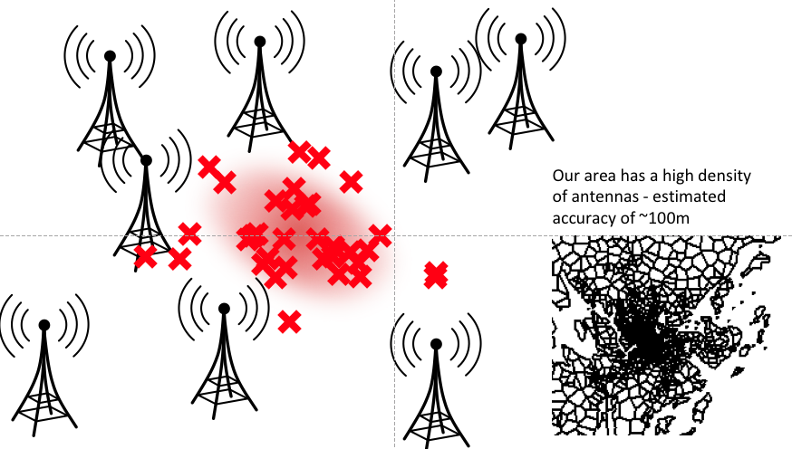

location

AND the cool thing is that unlike some other methods, this is fairly fast, so one can exploit big data sets. We may still be wrong occasionally, but in the aggregate, most approximations are pretty good.

### Phone data for comparison

To create comparable input sets, we select commute hours for the phone data so it is theoretically close to the once-a-year survey: we choose a ‘boring’ month, a ’boring’ day and the most ‘boring’ hours - Tuesdays of November 2016

Phones are assigned diurnal fixed **home** values based on the values of the mast where the longest time was spent between 00:00-07:00 Phones are assigned **work** place based on location between 09:00-17:00 **Mobility** 09:00-15:00 to contain all those that go to work late

### Method

1. Process data – calculate locations
2. Calculate flows aggregated to 1 km²
3. Fill OD matrix for both datasets
4. Calculate accessibility $A_j$
5. Compare accessibility values

Accessibility calculation (Hansen 1959):
$$A_j=\frac{F_{ij}}{\sum{d^{-\beta}}}$$
, where: $F_{ij}$ are the registered (PLACE) or revealed (MIND) flow of people from i to j, $\beta=0.000115$ for both datasets, estimated with Half-Life Model: $\beta= ln(0.5)/m$ , where $m=6010$ is the median distance in meters in Stockholm (Östh, Lyhagen & Reggiani, 2016), and $d$ is the distance from $i$ to $j$ in meters as crow flies

useful code snippets:

for flow analysis we generate unique ids from x y coordinates:

```r
install.packages('RStata')
```

```stata
use "OD_FLOWS_PHONES_AGG.dta" , clear
gen oid = string(kmyo) + "000" + string(kmxo)
gen did = string(kmyd) + "000" + string(kmxd)
```

Figures

this command:

```latex
\begin{figure}[h!]
    \center
    \includegraphics[width=0.3\textwidth]
    {ligatures_latex} \caption{Correct use of ligatures in \LaTeX (Source:
    \href{http://nitens.org/ taraborelli/latex}
    {Taborelli})}
\end{figure}
```

The command `h!` states that the figure should very explicitly (the ! command) be placed about here (the h command).

From here … into the abyss  
run `rmarkdown::render("file path")`

[^1]: So we do not forget